# Calibration model

Zoey Werbin, Ryan Quinn, Steve Gougherty, Yetianjian Wang

3/29/2019

In this markdown document, we’ll run through the creation of our dynamic linear models for the “historical” data from 5 NEON sites. We will model the ratio of bacteria and archaea (as one combined group) to fungi. Our current covariates are daily precipitation and minimum daily temperature, both averaged to the month level.

We have other covariates that describe each site, such as mean canopy height, and climate descriptors (MAP and MAT). These can later be incorporated into a hierarchical model that ties together our 5 sites. We also have time-series covariates such as pH, C:N ratio, and soil temperature, that we hope to include if we receive more data from NEON - in this historical time-series, we only have 1-3 values for each of these soil chemical or physical characteristics.

First, let’s run the script that will download and aggregate our covariate data, and read in the output. This will only run correctly if our working directory is the project directory - confirm that here:

```r
knitr::opts_knit$set(root.dir = rprojroot::find_rstudio_root_file())
#setwd("..")
print(getwd())
```

```
## [1] "/Users/zoeywerbin/SOaP"
```

Load directories:

```
## Linked to JAGS 4.3.0
```

```
## Loaded modules: basemod,bugs
```

Now, let’s format our data object. First we’ll look at the diagnostics for one of our sites, STER, in-depth. Later we’ll loop through and look at the model fits for the other four sites.

```r
# source file that downloads/aggregates all of the data - only need to run once. takes less than 2 min on a mac, takes much longer on non-Macs due to something (?) with the neonUtilities pacakge.
if(!file.exists("data/calibration_model_data.rds")){
  source("data_construction/aggregate_calibration_data.R")
}
### read in dataframe with response variable and covariates
df <- readRDS("data/calibration_model_data.rds")

# extract data from STER site
site.data <- df[df$siteID=="STER",]
  y <- site.data$ratio

  # convert dateID to date
  time <- site.data$dateID
  time <- as.yearmon(time, format="%Y-%m")
  time <- as.Date(time, format="%Y-%m")

  # set up data object
  z <- cbind(rep(1,length(y)), site.data$min_temp.C_avg, site.data$precip.mm_avg)
  colnames(z) <- c("betaIntercept", "betaTmin", "betaPrecip")
  data <- list(y=log(y),n=length(y), x_ic = 0,tau_ic = 0.00001,a_obs=0.1,
                r_obs=0.1,a_add=0.1,r_add=0.1)
  data[["Z"]] <- z
```

```r
ourmodel <- "model{

#### Priors
x[1] ~ dnorm(x_ic,tau_ic)
tau_obs ~ dgamma(a_obs,r_obs)
tau_add ~ dgamma(a_add,r_add)

#### Random Effects
tau_alpha~dgamma(0.1,0.1)
for(i in 1:n){
alpha[i]~dnorm(0,tau_alpha)
}

#### Fixed Effects
beta_IC~dnorm(0,0.001)
betaIntercept~dnorm(0,0.001)
betaTmin~dnorm(0,0.001)
betaPrecip~dnorm(0,0.001)

muTmin~dnorm(0,0.001)
muPrecip~dgamma(0.01,0.01)

tauTmin~dgamma(0.01,0.01)
tauPrecip~dgamma(0.01,0.01)

#### Data Model
for(t in 1:n){
y[t] ~ dnorm(x[t],tau_obs)
# missing data model:
Z[t,2] ~ dnorm(muTmin,tauTmin)
Z[t,3] ~ dnorm(muPrecip,tauPrecip)
}

#### Process Model
for(t in 2:n){
mu[t] <- beta_IC*x[t-1]  + betaIntercept*Z[t,1] + betaTmin*Z[t,2] + betaPrecip*Z[t,3] + alpha[t[i]]
x[t]~dnorm(mu[t],tau_add)
}

}"
```

Here we run the model and assess convergence, and check whether parameters are correlated.

```r
  j.model   <- jags.model (file = textConnection(ourmodel),
                           data = data,
                          # inits = init,
                           n.chains = 3)
```

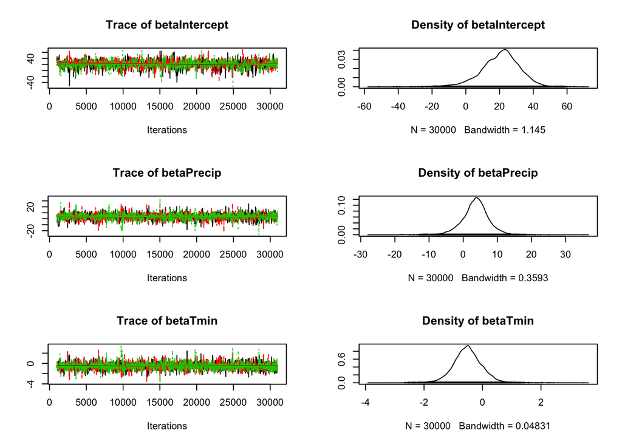

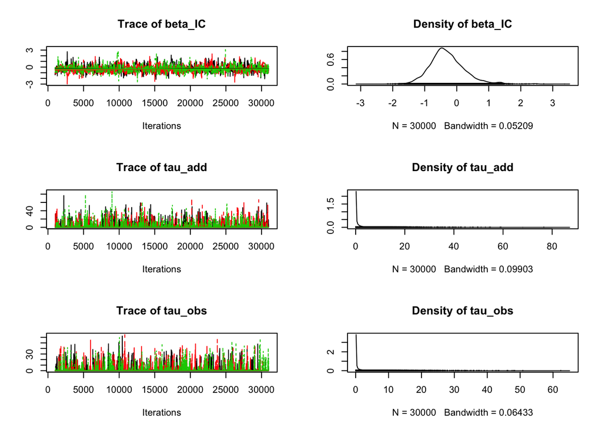

```r
  jags.out   <- coda.samples (model = j.model,
                              variable.names = c("tau_add","tau_obs", "beta_IC", "betaIntercept", "betaTmin",
                                                 "betaPrecip"),
                              n.iter = 30000)
  # view trace plots
  plot(jags.out)
```

```r
  # check psrf scores; we want these to be under 1.1
  gelman.diag(jags.out)
```

```
## Potential scale reduction factors:
##
##               Point est. Upper C.I.
## betaIntercept       1.01       1.02
## betaPrecip          1.00       1.01
## betaTmin            1.00       1.01
## beta_IC             1.01       1.02
## tau_add             1.00       1.00
## tau_obs             1.01       1.02
##
## Multivariate psrf
##
## 1.01
```

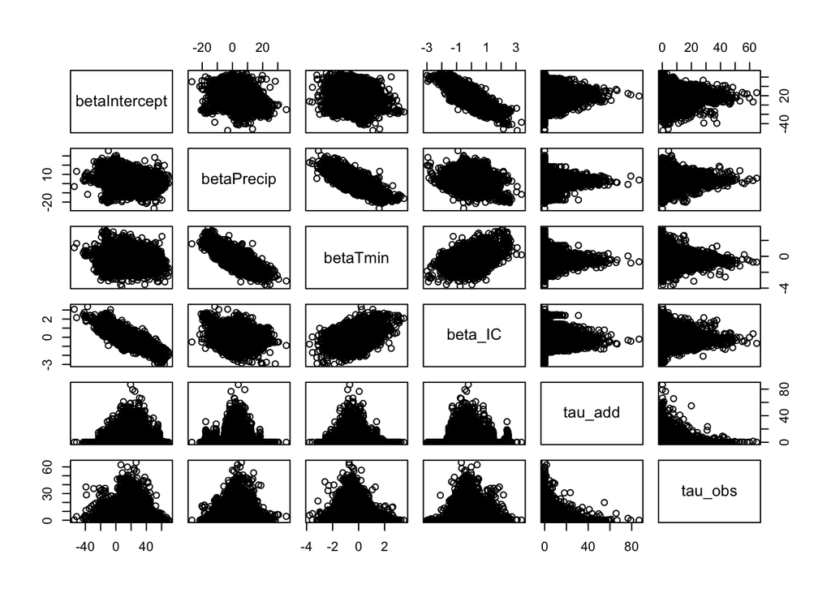

```r
  # plot correlation matrix of all of our parameters
  out <- as.matrix(jags.out)
  pairs(out)
```

```r
  jags.out   <- coda.samples (model = j.model,
                              variable.names = c("x","tau_add",
                              "tau_obs", "beta_IC", "betaIntercept",
                              "betaTmin", "betaPrecip","tau_alpha","alpha"),
                              n.iter = 30000)
```

Let’s visualize the model fit. This site has 10 dates, but other sites have even fewer, so this will likely be our best-fitting model.

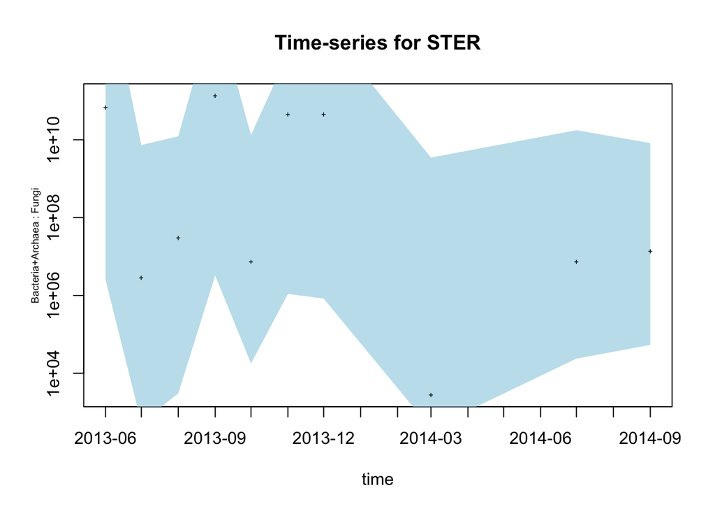

```r
  # plot fit with confidence interval
  time.rng = c(1,length(time)) ## adjust to zoom in and out
  out <- as.matrix(jags.out)
  x.cols <- grep("^x",colnames(out)) ## grab all columns that start with the letter x
  ci <- apply(exp(out[,x.cols]),2,quantile,c(0.025,0.5,0.975)) ## model was fit on log scale

  plot(time, ci[2,], type='n', ylim=range(y,na.rm=TRUE), ylab="",
       log='y', xlim=time[time.rng], xaxt="n",
       main="Time-series for STER")
  mtext(text = "Bacteria+Archaea : Fungi", side=2, line=2,cex=0.6)

  ## adjust x-axis labels
  axis.Date(1, at=seq(time[time.rng[1]],time[time.rng[2]],by='month'), format = "%Y-%m")
  ecoforecastR::ciEnvelope(time,ci[1,],ci[3,],col=ecoforecastR::col.alpha("lightBlue",0.75))
  points(time,y,pch="+",cex=0.5)
```

Our confidence interval is quite large. Hopefully it will be constrained by future improvements in our microbial abundance data processing, as well as incorporation of spatial information.

Now let’s view all 5 sites together! We have to run this for an increased number of iterations, otherwise our HARV site (which only has 5 observations) won’t converge. We fit the models using log scale, but we’ll view the values un-logged.

```
##
##
## [1] "Model diagnostics for site: DSNY"
## Potential scale reduction factors:
##
##               Point est. Upper C.I.
## betaIntercept       1.01       1.01
## betaPrecip          1.01       1.02
## betaTmin            1.01       1.01
## beta_IC             1.00       1.01
## tau_add             1.00       1.00
## tau_obs             1.00       1.00
##
## Multivariate psrf
##
## 1
```

```
##
##
## [1] "Model diagnostics for site: HARV"
## Potential scale reduction factors:
##
##               Point est. Upper C.I.
## betaIntercept       1.01       1.01
## betaPrecip          1.01       1.01
## betaTmin            1.02       1.02
## beta_IC             1.00       1.01
## tau_add             1.00       1.00
## tau_obs             1.00       1.00
##
## Multivariate psrf
##
## 1
```

```
##
##
## [1] "Model diagnostics for site: OSBS"
## Potential scale reduction factors:
##
##               Point est. Upper C.I.
## betaIntercept       1.03       1.08
## betaPrecip          1.00       1.01
## betaTmin            1.02       1.04
## beta_IC             1.04       1.11
## tau_add             1.00       1.00
## tau_obs             1.00       1.00
##
## Multivariate psrf
##
## 1.02
```

```
##
##
## [1] "Model diagnostics for site: CPER"
## Potential scale reduction factors:
##
##               Point est. Upper C.I.
## betaIntercept       1.01       1.02
## betaPrecip          1.01       1.02
## betaTmin            1.00       1.02
## beta_IC             1.00       1.01
## tau_add             1.00       1.00
## tau_obs             1.00       1.00
##
## Multivariate psrf
##
## 1.01
```

```
##
##
## [1] "Model diagnostics for site: STER"
## Potential scale reduction factors:
##
##               Point est. Upper C.I.
## betaIntercept          1       1.00
## betaPrecip             1       1.00
## betaTmin               1       1.01
## beta_IC                1       1.00
## tau_add                1       1.00
## tau_obs                1       1.00
##
## Multivariate psrf
##
## 1
```

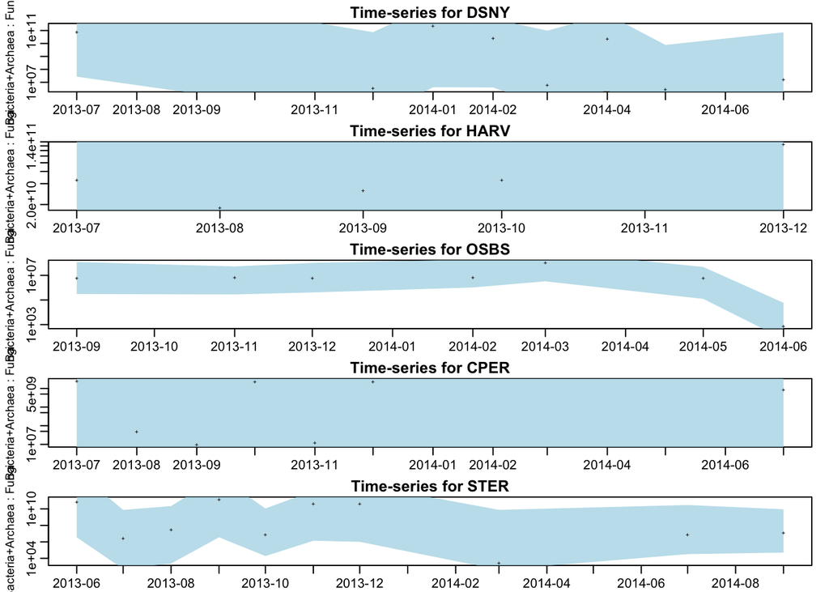

```r
par(mfrow=c(5,1), mar=c(1.7,3.1,1.5,1.1), mgp=c(3,.6,0))
# loop through all 5 sites
sites <- c("DSNY", "HARV", "OSBS", "CPER", "STER")
for(s in 1:length(sites)) {

  site.data <- df[df$siteID==sites[s],]
  y <- site.data$ratio

  # convert dateID to date
  time <- site.data$dateID
  time <- as.yearmon(time, format="%Y-%m")
  time <- as.Date(time, format="%Y-%m")

   # set up data object
  z <- cbind(rep(1,length(y)), site.data$min_temp.C_avg, site.data$precip.mm_avg)
  colnames(z) <- c("betaIntercept", "betaTmin", "betaPrecip")
  data <- list(y=log(y),n=length(y), x_ic = 0,tau_ic = 0.00001,a_obs=0.1,
                r_obs=0.1,a_add=0.1,r_add=0.1)
  data[["Z"]] <- z


  j.model   <- jags.model (file = textConnection(ourmodel),
                           data = data,
                           n.chains = 3)

  jags.out   <- coda.samples (model = j.model,
                              variable.names = c("tau_add","tau_obs", "beta_IC", "betaIntercept", "betaTmin",
                                                 "betaPrecip"),
                              n.iter = 80000)
  print(paste0("Model diagnostics for site: ", sites[s]))
  print(gelman.diag(jags.out)) # check psrf scores for each model

  jags.out   <- coda.samples (model = j.model,
                              variable.names = c("x","tau_add",
                              "tau_obs", "beta_IC", "betaIntercept",
                              "betaTmin", "betaPrecip",
                              "tau_alpha","alpha"),
                              n.iter = 100000)


  # plot fit with confidence interval
  time.rng = c(1,length(time))
  out <- as.matrix(jags.out)
  x.cols <- grep("^x",colnames(out)) ## grab all columns that start with the letter x
  ci <- apply(exp(out[,x.cols]),2,quantile,c(0.025,0.5,0.975)) ## model was fit on log scale

  plot(time, ci[2,], type='n', ylim=range(y,na.rm=TRUE), ylab="",
       log='y', xlim=time[time.rng], xaxt="n",
       main=paste0("Time-series for ",sites[s]))
  mtext(text = "Bacteria+Archaea : Fungi", side=2, line=2,cex=0.6)

  ## adjust x-axis labels
  axis.Date(1, at=seq(time[time.rng[1]],time[time.rng[2]],by='month'), format = "%Y-%m")
  ecoforecastR::ciEnvelope(time,ci[1,],ci[3,],col=ecoforecastR::col.alpha("lightBlue",0.75))
  points(time,y,pch="+",cex=0.5)
}
```